# CS5801 Coursework Template Proforma

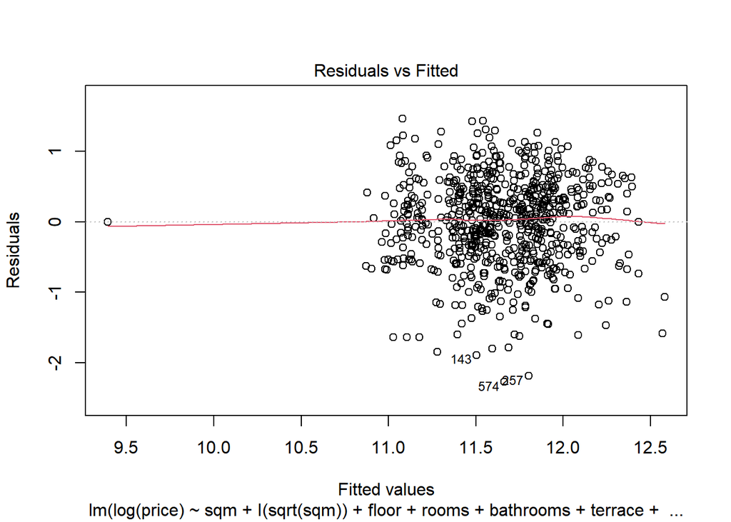

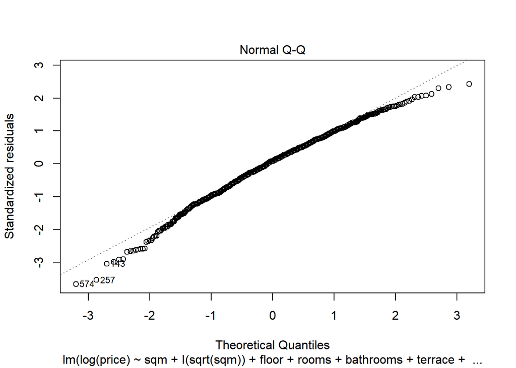

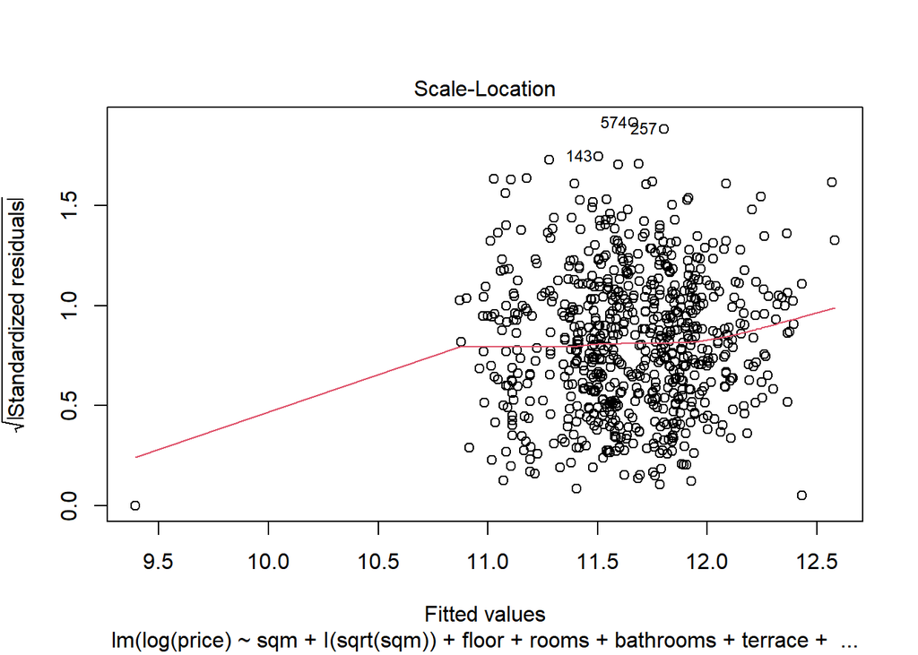

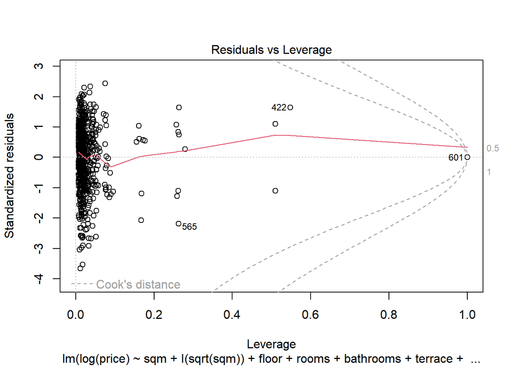

```r
plot(df.lm2)
```

Now, after applying a log transformation, different results are obtained: The number of rooms becomes also significant. “Sqm” becomes slightly significant, while the square rooted “sqm” term is much more significant, thus the latter should be kept. Looking at the residuals, the first plot does not show further signs of heteroskedasticity. On the other hand, the QQ plot does not point to further issues, except for the data being skewed. There are also a couple of outliers spotted, but no further action will be performed at this point.

Now, to obtain the minimal adequate model, the step function is applied:

```r
df.lm3<-step(df.lm2)
```

```
## Start:  AIC=-661.58
## log(price) ~ sqm + I(sqrt(sqm)) + floor + rooms + bathrooms +
##     terrace + alarm + heating + ac + parking + furnished
##
##                Df Sum of Sq    RSS     AIC
## - floor         6    1.0366 274.25 -670.84
## - furnished     1    0.0179 273.24 -663.53
## - ac            1    0.1709 273.39 -663.13
## - parking       1    0.2815 273.50 -662.83
## - alarm         1    0.2853 273.50 -662.82
## - heating       1    0.3688 273.59 -662.60
## <none>                      273.22 -661.58
## - sqm           1    1.6107 274.83 -659.33
## - I(sqrt(sqm))  1    4.0792 277.30 -652.86
## - terrace       1    6.2266 279.44 -647.29
## - rooms         4   10.3955 283.61 -642.58
## - bathrooms     2    9.4562 282.67 -640.98
##
## Step:  AIC=-670.84
## log(price) ~ sqm + I(sqrt(sqm)) + rooms + bathrooms + terrace +
##     alarm + heating + ac + parking + furnished
##
##                Df Sum of Sq    RSS     AIC
## - furnished     1    0.0144 274.27 -672.80
## - ac            1    0.1547 274.41 -672.43
## - parking       1    0.2061 274.46 -672.30
## - alarm         1    0.3205 274.57 -672.00
## - heating       1    0.3224 274.58 -671.99
## <none>                      274.25 -670.84
## - sqm           1    1.4492 275.70 -669.03
## - I(sqrt(sqm))  1    3.8576 278.11 -662.74
## - terrace       1    6.2986 280.55 -656.42
## - rooms         4   10.7950 285.05 -650.93
## - bathrooms     2    9.7508 284.01 -649.58
##
## Step:  AIC=-672.8
## log(price) ~ sqm + I(sqrt(sqm)) + rooms + bathrooms + terrace +
##     alarm + heating + ac + parking
##
##                Df Sum of Sq    RSS     AIC
```

[output cut: 48 more lines]

```
## - I(sqrt(sqm))  1    3.7556 278.73 -669.13
## - terrace       1    6.8169 281.79 -661.24
## - rooms         4   10.9480 285.92 -656.71
## - bathrooms     2    9.7541 284.73 -655.74
##
## Step:  AIC=-677.93
## log(price) ~ sqm + I(sqrt(sqm)) + rooms + bathrooms + terrace
##
##                Df Sum of Sq    RSS     AIC
## <none>                      275.36 -677.93
## - sqm           1    1.4203 276.78 -676.21
## - I(sqrt(sqm))  1    3.7865 279.15 -670.05
## - terrace       1    6.9115 282.27 -662.00
## - rooms         4   11.2082 286.57 -657.08
## - bathrooms     2    9.6698 285.03 -656.97
```

```r
summary(df.lm3)
```

```
##
## Call:
## lm(formula = log(price) ~ sqm + I(sqrt(sqm)) + rooms + bathrooms +
##     terrace, data = train)
##
## Residuals:
##      Min       1Q   Median       3Q      Max
## -2.31066 -0.40083  0.05948  0.43522  1.50763
##
## Coefficients:
##               Estimate Std. Error t value Pr(>|t|)
## (Intercept)   8.253947   0.691315  11.939  < 2e-16 ***
## sqm          -0.002900   0.001512  -1.918 0.055546 .
## I(sqrt(sqm))  0.135718   0.043344   3.131 0.001812 **
## rooms2        1.982555   0.626237   3.166 0.001612 **
## rooms3        2.260382   0.623477   3.625 0.000309 ***
## rooms4        2.217356   0.623969   3.554 0.000405 ***
## rooms5        2.131113   0.624717   3.411 0.000683 ***
## bathrooms2    0.256499   0.054065   4.744 2.53e-06 ***
## bathrooms3    0.364672   0.129896   2.807 0.005130 **
## terrace1      0.290648   0.068705   4.230 2.64e-05 ***
## ---
## Signif. codes:  0 '***' 0.001 '**' 0.01 '*' 0.05 '.' 0.1 ' ' 1
##
## Residual standard error: 0.6215 on 713 degrees of freedom
## Multiple R-squared:  0.2174, Adjusted R-squared:  0.2076
## F-statistic: 22.01 on 9 and 713 DF,  p-value: < 2.2e-16
```

The F-statistic remains significant, and the r-squared very low. Thus, we can conclude that the model’s performance is not satisfactory and does not have enough explanatory power to accurately predict property price. On the other hand, we can confirm there is a statistical difference in the mean property price depending on the number of rooms, as well as in the number of bathrooms, and having a terrace.

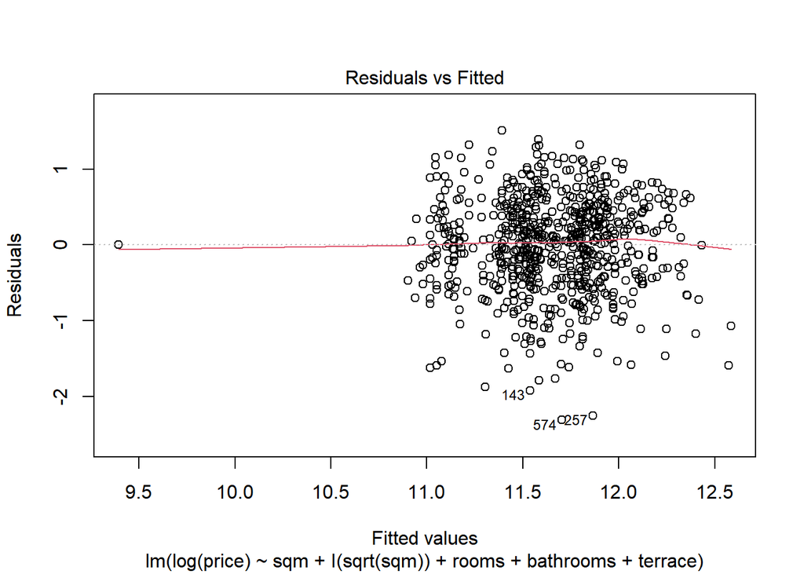

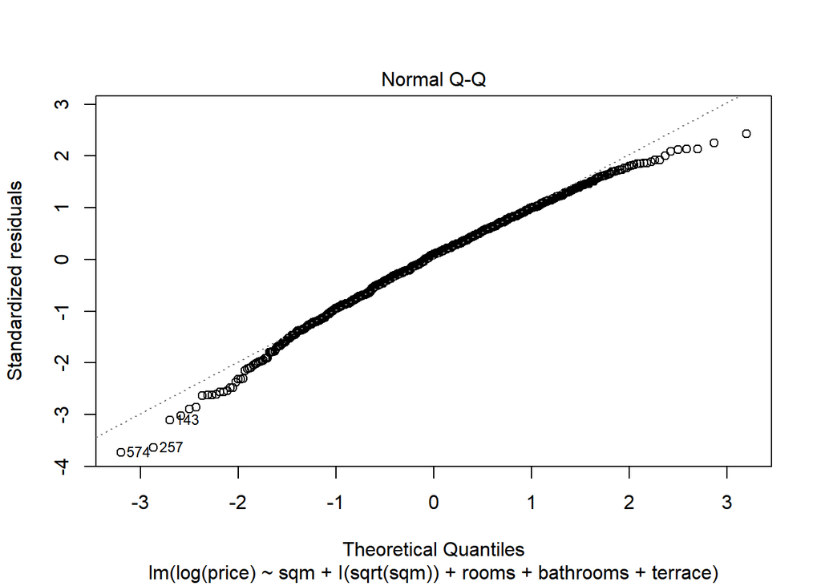

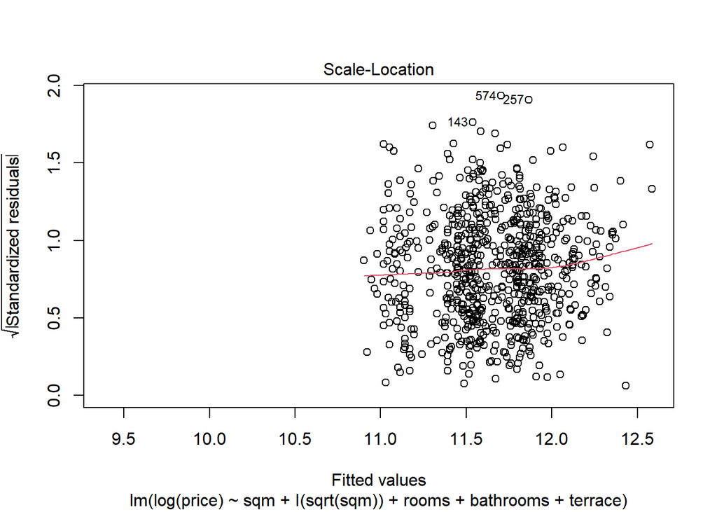

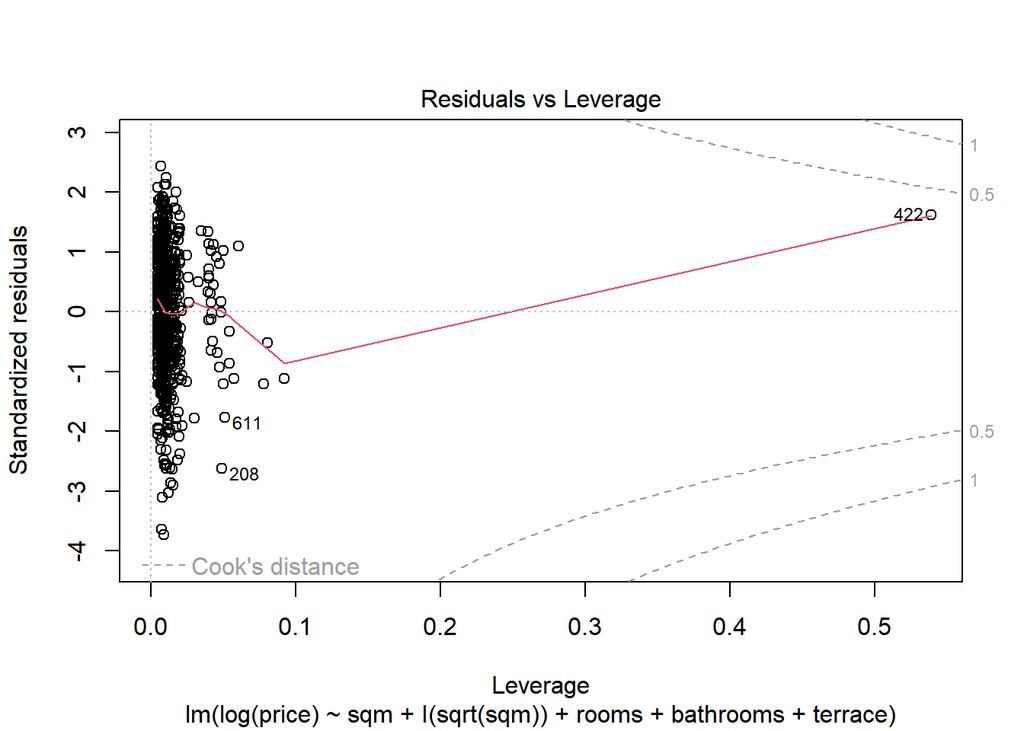

```r
plot(df.lm3)
```

The residuals remain the same. The minimal adequate model is:

With the hopes of obtaining a more accurate model, we can take the variables selected by the minimal adequate model after applying the step function, and develop a new model with those variables and including interactions:

```r
df.lm4<-lm(log(price)~ I(sqrt(sqm)) * rooms * bathrooms * terrace, data = train)
summary(df.lm4)
```

```
##
## Call:
## lm(formula = log(price) ~ I(sqrt(sqm)) * rooms * bathrooms *
##     terrace, data = train)
##
## Residuals:
##      Min       1Q   Median       3Q      Max
## -2.36241 -0.38051  0.03209  0.43303  1.53336
##
## Coefficients: (19 not defined because of singularities)
##                                           Estimate Std. Error t value Pr(>|t|)
## (Intercept)                              8.8853150  0.7031489  12.636  < 2e-16
## I(sqrt(sqm))                             0.0463142  0.0309179   1.498  0.13460
## rooms2                                   1.8700706  0.7894396   2.369  0.01812
## rooms3                                   1.9643078  0.7739202   2.538  0.01137
## rooms4                                   1.8091924  0.8216810   2.202  0.02801
## rooms5                                   2.0068282  0.6242970   3.215  0.00137
## bathrooms2                               0.5315198  0.5073582   1.048  0.29518
## bathrooms3                              -1.2615639  1.2835471  -0.983  0.32602
## terrace1                                 0.0068913  2.0634836   0.003  0.99734
## I(sqrt(sqm)):rooms2                     -0.0009423  0.0540367  -0.017  0.98609
## I(sqrt(sqm)):rooms3                      0.0330881  0.0463247   0.714  0.47531
## I(sqrt(sqm)):rooms4                      0.0251634  0.0502621   0.501  0.61678
## I(sqrt(sqm)):rooms5                             NA         NA      NA       NA
## I(sqrt(sqm)):bathrooms2                 -0.0035210  0.0393702  -0.089  0.92876
## I(sqrt(sqm)):bathrooms3                  0.1307064  0.0933841   1.400  0.16207
## rooms2:bathrooms2                       -1.9640403  1.8915611  -1.038  0.29949
## rooms3:bathrooms2                       -0.2977367  0.6643034  -0.448  0.65416
## rooms4:bathrooms2                       -0.0468256  0.7803169  -0.060  0.95217
## rooms5:bathrooms2                               NA         NA      NA       NA
## rooms2:bathrooms3                               NA         NA      NA       NA
## rooms3:bathrooms3                       -1.4868320  4.1176960  -0.361  0.71815
## rooms4:bathrooms3                        2.2493329  1.5593489   1.442  0.14963
## rooms5:bathrooms3                               NA         NA      NA       NA
## I(sqrt(sqm)):terrace1                    0.0254889  0.1825610   0.140  0.88900
## rooms2:terrace1                          1.0766526  2.2303318   0.483  0.62944
## rooms3:terrace1                          1.8098212  2.4038023   0.753  0.45177
## rooms4:terrace1                          1.3841339  3.1492276   0.440  0.66043
## rooms5:terrace1                                 NA         NA      NA       NA
## bathrooms2:terrace1                      0.8126784  2.4295688   0.334  0.73811
```

[output cut: 83 more lines]

```
## rooms5:bathrooms3:terrace1
## I(sqrt(sqm)):rooms2:bathrooms2:terrace1
## I(sqrt(sqm)):rooms3:bathrooms2:terrace1
## I(sqrt(sqm)):rooms4:bathrooms2:terrace1
## I(sqrt(sqm)):rooms5:bathrooms2:terrace1
## I(sqrt(sqm)):rooms2:bathrooms3:terrace1
## I(sqrt(sqm)):rooms3:bathrooms3:terrace1
## I(sqrt(sqm)):rooms4:bathrooms3:terrace1
## I(sqrt(sqm)):rooms5:bathrooms3:terrace1
## ---
## Signif. codes:  0 '***' 0.001 '**' 0.01 '*' 0.05 '.' 0.1 ' ' 1
##
## Residual standard error: 0.6162 on 682 degrees of freedom
## Multiple R-squared:  0.2641, Adjusted R-squared:  0.2209
## F-statistic: 6.118 on 40 and 682 DF,  p-value: < 2.2e-16
```

Although the model performance increases slightly (r2 = 0.22), there are not significant interactions, as shown in the summary above. To conclude, even if the model obtained is not a good predictor for property price, the ANCOVA model with the best performance is the one including square rooted “sqm”, “rooms”, “bathrooms” and “terrace”, as well as interactions.

```r
df.lm5<-lm(log(price)~ I(sqrt(sqm)) * rooms * bathrooms * terrace, data = test)
summary(df.lm5)
```

```
##
## Call:
## lm(formula = log(price) ~ I(sqrt(sqm)) * rooms * bathrooms *
##     terrace, data = test)
##
## Residuals:
##     Min      1Q  Median      3Q     Max
## -1.8146 -0.3484  0.0000  0.4172  1.6153
##
## Coefficients: (13 not defined because of singularities)
##                                         Estimate Std. Error t value Pr(>|t|)
## (Intercept)                              9.23677    0.99306   9.301  < 2e-16
## I(sqrt(sqm))                             0.24547    0.12902   1.903  0.05907
## rooms3                                   1.62748    1.11125   1.465  0.14519
## rooms4                                   1.12143    1.15956   0.967  0.33509
## rooms5                                   4.25879    1.63834   2.599  0.01030
## bathrooms2                               3.23780    1.58551   2.042  0.04294
## bathrooms3                              -0.09234    3.79508  -0.024  0.98062
## terrace1                                 2.46138    1.22891   2.003  0.04704
## I(sqrt(sqm)):rooms3                     -0.17577    0.13887  -1.266  0.20763
## I(sqrt(sqm)):rooms4                     -0.13148    0.14169  -0.928  0.35499
## I(sqrt(sqm)):rooms5                     -0.47392    0.17459  -2.714  0.00744
## I(sqrt(sqm)):bathrooms2                 -0.45330    0.18802  -2.411  0.01716
## I(sqrt(sqm)):bathrooms3                  0.15621    0.27160   0.575  0.56608
## rooms3:bathrooms2                       -2.85279    1.71153  -1.667  0.09770
## rooms4:bathrooms2                       -3.43766    1.99176  -1.726  0.08647
## rooms5:bathrooms2                       -4.20352    2.19803  -1.912  0.05778
## rooms3:bathrooms3                        2.33685    6.16428   0.379  0.70517
## rooms4:bathrooms3                       24.42116   12.66044   1.929  0.05568
## rooms5:bathrooms3                             NA         NA      NA       NA
## I(sqrt(sqm)):terrace1                   -0.29893    0.14784  -2.022  0.04500
## rooms3:terrace1                          0.10953    5.26641   0.021  0.98343
## rooms4:terrace1                         -0.88348    4.35193  -0.203  0.83941
## rooms5:terrace1                         -2.09986    5.67878  -0.370  0.71209
## bathrooms2:terrace1                     -1.01625    4.59329  -0.221  0.82521
## bathrooms3:terrace1                      0.67186    1.65508   0.406  0.68538
## I(sqrt(sqm)):rooms3:bathrooms2           0.44559    0.19760   2.255  0.02562
## I(sqrt(sqm)):rooms4:bathrooms2           0.48730    0.21541   2.262  0.02516
## I(sqrt(sqm)):rooms5:bathrooms2           0.63620    0.23024   2.763  0.00646
## I(sqrt(sqm)):rooms3:bathrooms3          -0.25906    0.42024  -0.616  0.53856
```

[output cut: 59 more lines]

```
## rooms3:bathrooms3:terrace1
## rooms4:bathrooms3:terrace1
## rooms5:bathrooms3:terrace1
## I(sqrt(sqm)):rooms3:bathrooms2:terrace1
## I(sqrt(sqm)):rooms4:bathrooms2:terrace1
## I(sqrt(sqm)):rooms5:bathrooms2:terrace1
## I(sqrt(sqm)):rooms3:bathrooms3:terrace1
## I(sqrt(sqm)):rooms4:bathrooms3:terrace1
## I(sqrt(sqm)):rooms5:bathrooms3:terrace1
## ---
## Signif. codes:  0 '***' 0.001 '**' 0.01 '*' 0.05 '.' 0.1 ' ' 1
##
## Residual standard error: 0.6097 on 146 degrees of freedom
## Multiple R-squared:  0.4115, Adjusted R-squared:  0.2744
## F-statistic: 3.002 on 34 and 146 DF,  p-value: 2.658e-06
```

Interestingly, some interactions become significant and the goodness of fit (r-squared) increases for the test sample.

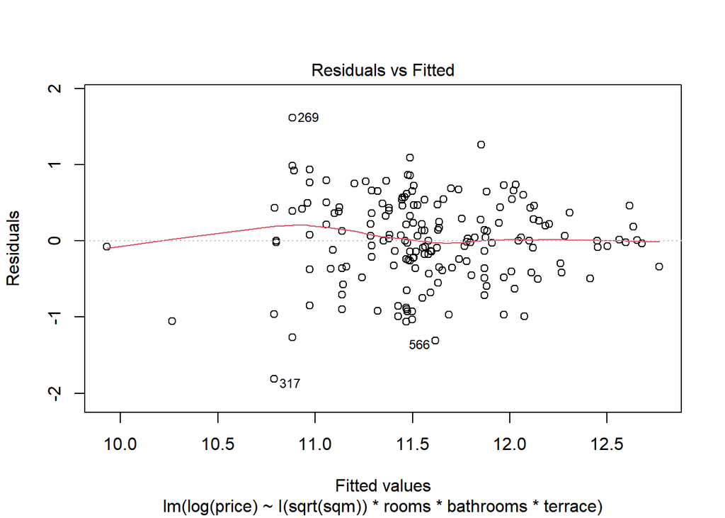

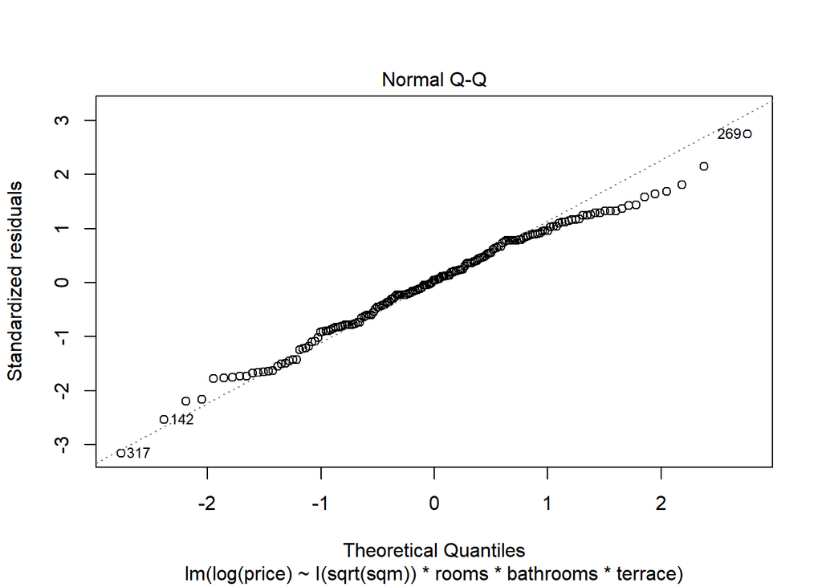

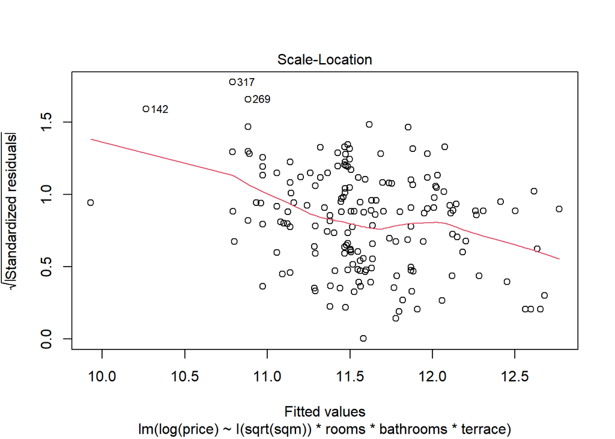

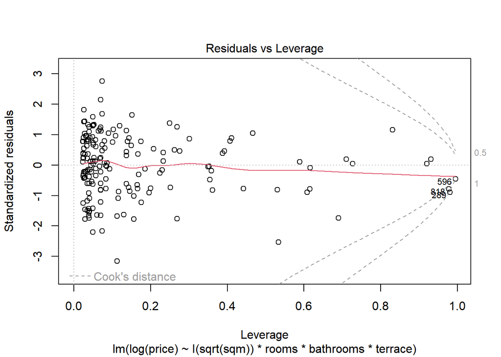

```r
plot(df.lm5)
```

## 3.3 Critique model using relevant diagnostics

Summarizing the findings made in the previous point:

## 3.4 Suggest improvements to your model

As seen in the EDA, the uneven distributions for the binary variables do not provide much explanatory power. Furthermore, important information is missing from the dataframe in my opinion. Firstly, the area or neighborhood should be a factor included, as this could be a key factor when determining property price. Also, as mentioned previously, the property type should be addressed as well, to differ from apartments and bigger houses.

It was previously hypothesized in 2.3 after looking at the scatter plots that higher values of “sqm” and “rooms” increased the variability of “price”. This might be due to the following reason: neighborhoods in the peripheral areas of a city allow for bigger houses, with higher square meters and number of rooms, at a lower cost, while apartments in a central area of a city tend to be smaller, with higher prices. Thus, with the aim of obtaining a more robust model for apartment price prediction, let’s try and build a model removing big houses (> 200 sqm). Although this hypothesis is very rudimentary (as it involves getting rid of many rows), the purpose is to see whether smaller sized apartments benefit the model performance.:

```r
df2 <- df[-c(which(df$sqm>200)), ]
```

```r
df2.lm<-lm(log(df2$price)~df2$sqm + I(sqrt(df2$sqm)) + df2$floor + df2$rooms +df2$bathrooms + df2$terrace + df2$alarm + df2$heating + df2$ac + df2$parking + df2$furnished)
summary(df2.lm)
```

```
##
## Call:
## lm(formula = log(df2$price) ~ df2$sqm + I(sqrt(df2$sqm)) + df2$floor +
##     df2$rooms + df2$bathrooms + df2$terrace + df2$alarm + df2$heating +
##     df2$ac + df2$parking + df2$furnished)
##
## Residuals:
##     Min      1Q  Median      3Q     Max
## -2.3742 -0.3770  0.0362  0.4209  1.5952
##
## Coefficients:
##                   Estimate Std. Error t value Pr(>|t|)
## (Intercept)       6.855807   0.889777   7.705 3.80e-14 ***
## df2$sqm          -0.016339   0.005791  -2.821 0.004896 **
## I(sqrt(df2$sqm))  0.410565   0.120570   3.405 0.000694 ***
## df2$floor2        0.078939   0.049493   1.595 0.111111
## df2$floor3       -0.021088   0.066725  -0.316 0.752055
## df2$floor4        0.065892   0.115525   0.570 0.568581
## df2$floor5       -0.067351   0.164852  -0.409 0.682974
## df2$floor6        0.409301   0.363326   1.127 0.260268
## df2$floor7        0.116933   0.443554   0.264 0.792134
## df2$rooms2        2.028866   0.625240   3.245 0.001223 **
## df2$rooms3        2.241931   0.621920   3.605 0.000331 ***
## df2$rooms4        2.177512   0.622203   3.500 0.000491 ***
## df2$rooms5        2.144007   0.623637   3.438 0.000616 ***
## df2$bathrooms2    0.266112   0.050937   5.224 2.22e-07 ***
## df2$bathrooms3    0.370575   0.151179   2.451 0.014446 *
## df2$terrace1      0.306986   0.064741   4.742 2.50e-06 ***
## df2$alarm1        0.240895   0.255839   0.942 0.346682
## df2$heatingother  0.059181   0.069306   0.854 0.393404
## df2$ac1           0.008099   0.047180   0.172 0.863745
## df2$parking1     -0.208679   0.199122  -1.048 0.294951
## df2$furnished1   -0.027217   0.084420  -0.322 0.747236
## ---
## Signif. codes:  0 '***' 0.001 '**' 0.01 '*' 0.05 '.' 0.1 ' ' 1
##
## Residual standard error: 0.6194 on 815 degrees of freedom
## Multiple R-squared:  0.2139, Adjusted R-squared:  0.1946
## F-statistic: 11.09 on 20 and 815 DF,  p-value: < 2.2e-16
```

```r
df2.lm2<-step(df2.lm)
```

```
## Start:  AIC=-780.19
## log(df2$price) ~ df2$sqm + I(sqrt(df2$sqm)) + df2$floor + df2$rooms +
##     df2$bathrooms + df2$terrace + df2$alarm + df2$heating + df2$ac +
##     df2$parking + df2$furnished
##
##                    Df Sum of Sq    RSS     AIC
## - df2$floor         6    1.8761 314.54 -787.19
## - df2$ac            1    0.0113 312.68 -782.16
## - df2$furnished     1    0.0399 312.71 -782.09
## - df2$heating       1    0.2797 312.95 -781.45
## - df2$alarm         1    0.3401 313.01 -781.28
## - df2$parking       1    0.4214 313.09 -781.07
## <none>                          312.67 -780.19
## - df2$sqm           1    3.0541 315.72 -774.07
## - I(sqrt(df2$sqm))  1    4.4485 317.12 -770.38
## - df2$rooms         4    8.7252 321.39 -765.18
## - df2$terrace       1    8.6258 321.29 -759.44
## - df2$bathrooms     2   11.2475 323.92 -754.65
##
## Step:  AIC=-787.19
## log(df2$price) ~ df2$sqm + I(sqrt(df2$sqm)) + df2$rooms + df2$bathrooms +
##     df2$terrace + df2$alarm + df2$heating + df2$ac + df2$parking +
##     df2$furnished
##
##                    Df Sum of Sq    RSS     AIC
## - df2$ac            1    0.0144 314.56 -789.15
## - df2$furnished     1    0.0611 314.61 -789.03
## - df2$heating       1    0.3161 314.86 -788.35
## - df2$parking       1    0.3821 314.93 -788.18
## - df2$alarm         1    0.4239 314.97 -788.07
## <none>                          314.54 -787.19
## - df2$sqm           1    3.1455 317.69 -780.87
## - I(sqrt(df2$sqm))  1    4.5132 319.06 -777.28
## - df2$rooms         4    8.9926 323.54 -771.63
## - df2$terrace       1    8.6468 323.19 -766.52
## - df2$bathrooms     2   11.7542 326.30 -760.52
##
## Step:  AIC=-789.15
## log(df2$price) ~ df2$sqm + I(sqrt(df2$sqm)) + df2$rooms + df2$bathrooms +
##     df2$terrace + df2$alarm + df2$heating + df2$parking + df2$furnished
```

[output cut: 51 more lines]

```
## - df2$rooms         4    9.1470 324.47 -777.23
## - df2$terrace       1    8.8236 324.14 -772.06
## - df2$bathrooms     2   11.4448 326.76 -767.33
##
## Step:  AIC=-793.96
## log(df2$price) ~ df2$sqm + I(sqrt(df2$sqm)) + df2$rooms + df2$bathrooms +
##     df2$terrace
##
##                    Df Sum of Sq    RSS     AIC
## <none>                          315.76 -793.96
## - df2$sqm           1    3.1346 318.90 -787.71
## - I(sqrt(df2$sqm))  1    4.4935 320.26 -784.15
## - df2$rooms         4    9.3278 325.09 -777.62
## - df2$terrace       1    9.0645 324.83 -772.30
## - df2$bathrooms     2   11.4238 327.19 -768.25
```

```r
summary(df2.lm2)
```

```
##
## Call:
## lm(formula = log(df2$price) ~ df2$sqm + I(sqrt(df2$sqm)) + df2$rooms +
##     df2$bathrooms + df2$terrace)
##
## Residuals:
##      Min       1Q   Median       3Q      Max
## -2.34791 -0.37940  0.04606  0.42981  1.56623
##
## Coefficients:
##                  Estimate Std. Error t value Pr(>|t|)
## (Intercept)       6.86493    0.88711   7.739 2.93e-14 ***
## df2$sqm          -0.01649    0.00576  -2.864 0.004296 **
## I(sqrt(df2$sqm))  0.41144    0.12000   3.429 0.000637 ***
## df2$rooms2        2.04983    0.62348   3.288 0.001053 **
## df2$rooms3        2.27374    0.62020   3.666 0.000262 ***
## df2$rooms4        2.21185    0.62052   3.564 0.000385 ***
## df2$rooms5        2.17361    0.62165   3.497 0.000497 ***
## df2$bathrooms2    0.26503    0.05056   5.241 2.02e-07 ***
## df2$bathrooms3    0.38693    0.15006   2.579 0.010092 *
## df2$terrace1      0.30669    0.06298   4.869 1.34e-06 ***
## ---
## Signif. codes:  0 '***' 0.001 '**' 0.01 '*' 0.05 '.' 0.1 ' ' 1
##
## Residual standard error: 0.6183 on 826 degrees of freedom
## Multiple R-squared:  0.2061, Adjusted R-squared:  0.1974
## F-statistic: 23.82 on 9 and 826 DF,  p-value: < 2.2e-16
```

As seen, removing the bigger properties has not helped, as the performance is very low (r2 = 0.19), thus, the hypothesis previously stated is not supported by evidence.

# 4. Extension work

## 4.1 Model the likelihood of a property being furnished (using the is_furnished variable provided).

Prior to modelling, some analysis and visualization has to be performed:

- What is the exact amount for furnished houses?

```r
table(df$furnished)
```

```
##
##   0   1
## 841  63
```

As we had seen previously in the EDA section, the distribution is very uneven.

- How is “furnished” distributed vs continuous numerical variables?

Recall these plots from the EDA section:

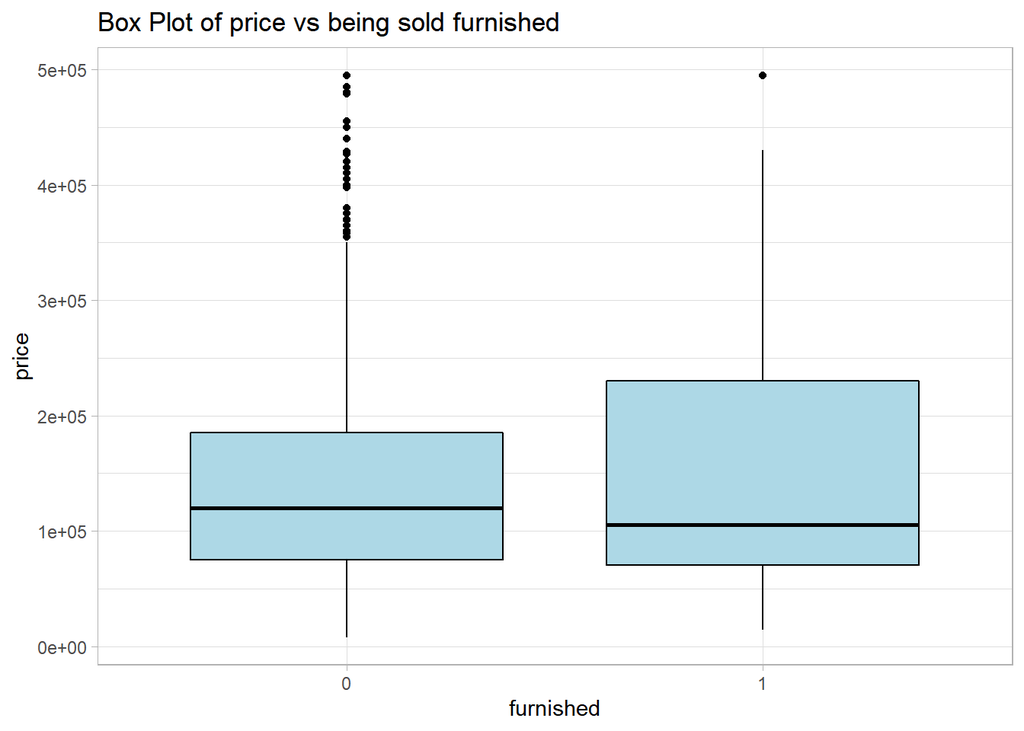

```r
#furnished vs price
ggplot(df, aes(x=price, y=furnished)) +
  geom_boxplot(colour = "black", fill="lightblue") +
  theme_light() +
  labs(title="Box Plot of price vs being sold furnished") +
  coord_flip()
```

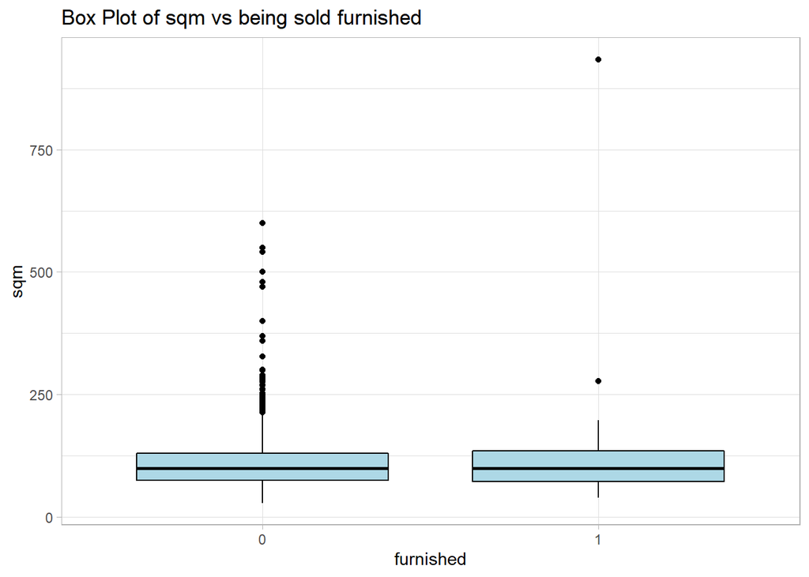

```r
#furnished vs sqm
ggplot(df, aes(x=sqm, y=furnished)) +
  geom_boxplot(colour = "black", fill="lightblue") +
  theme_light() +
  labs(title="Box Plot of sqm vs being sold furnished") +
  coord_flip()
```

In both plots many outliers can be observed, and there does not seem to be a difference in mean of “price” and “sqm” between furnished and not-furnished houses. EDA:

- check how is “furnished” distributed vs categorical variables

For this, we can simply portray contingency tables:

```r
#furnished vs floor
table(Furnished = df$furnished, Rooms = df$floor)
```

```
##          Rooms
## Furnished   1   2   3   4   5   6   7
##         0 411 267 107  34  16   5   1
##         1  32  17  12   1   0   0   1
```

```r
#furnished vs rooms
table(Furnished = df$furnished, Bathrooms = df$bathrooms)
```

```
##          Bathrooms
## Furnished   1   2   3
##         0 511 294  36
##         1  37  25   1
```

```r
#furnished vs terrace
table(Furnished = df$furnished, Terrace = df$terrace)
```

```
##          Terrace
## Furnished   0   1
##         0 731 110
##         1  52  11
```

```r
#furnished vs alarm
table(Furnished = df$furnished, Alarm = df$alarm)
```

```
##          Alarm
## Furnished   0   1
##         0 836   5
##         1  62   1
```

```r
#furnished vs heating
table(Furnished = df$furnished, Heating = df$heating)
```

```
##          Heating
## Furnished autonomous other
##         0        752    89
##         1         55     8
```

```r
#furnished vs ac
table(Furnished = df$furnished, AC = df$ac)
```

```
##          AC
## Furnished   0   1
##         0 573 268
##         1  25  38
```

```r
#furnished vs parking
table(Furnished = df$furnished, Parking = df$parking)
```

```
##          Parking
## Furnished   0   1
##         0 831  10
##         1  62   1
```

We can see that the vast majority of properties were not sold furnished, skewing the distributions. For instance, only one property with parking was sold furnished, or only on property with 3 bathrooms. Thus, no clear insight can be taken from this.

Now, the model can be presented. Since the dependent variable is binary, a logistic regression model will be applied. Note that the model will be trained with the training set, and later compared with the test set.

```r
furnished.glm<-glm(furnished ~ price + sqm + floor + rooms +bathrooms + terrace + alarm + heating + ac + parking, data = train, family = "binomial")
summary(furnished.glm)
```

```
##
## Call:
## glm(formula = furnished ~ price + sqm + floor + rooms + bathrooms +
##     terrace + alarm + heating + ac + parking, family = "binomial",
##     data = train)
##
## Deviance Residuals:
##     Min       1Q   Median       3Q      Max
## -0.9635  -0.4149  -0.2952  -0.2417   2.7354
##
## Coefficients:
##                Estimate Std. Error z value Pr(>|z|)
## (Intercept)  -1.877e+01  6.523e+03  -0.003 0.997704
## price         1.793e-06  1.649e-06   1.087 0.276951
## sqm           1.539e-03  1.993e-03   0.772 0.440230
## floor2        3.632e-02  3.428e-01   0.106 0.915638
## floor3        2.981e-01  4.188e-01   0.712 0.476614
## floor4       -1.616e+01  1.163e+03  -0.014 0.988916
## floor5       -1.608e+01  1.615e+03  -0.010 0.992053
## floor6       -1.616e+01  3.137e+03  -0.005 0.995889
## floor7        2.027e+00  1.553e+00   1.305 0.191786
## rooms2        1.576e+01  6.523e+03   0.002 0.998072
## rooms3        1.503e+01  6.523e+03   0.002 0.998161
## rooms4        1.509e+01  6.523e+03   0.002 0.998154
## rooms5        1.585e+01  6.523e+03   0.002 0.998062
## bathrooms2   -2.901e-01  3.615e-01  -0.803 0.422238
## bathrooms3   -1.240e+00  1.080e+00  -1.148 0.250914
## terrace1     -3.056e-01  4.483e-01  -0.682 0.495500
## alarm1        1.265e+00  1.230e+00   1.029 0.303615
## heatingother  3.749e-01  4.661e-01   0.804 0.421283
## ac1           1.120e+00  3.090e-01   3.625 0.000289 ***
## parking1      8.584e-01  1.182e+00   0.726 0.467589
## ---
## Signif. codes:  0 '***' 0.001 '**' 0.01 '*' 0.05 '.' 0.1 ' ' 1
##
## (Dispersion parameter for binomial family taken to be 1)
##
##     Null deviance: 373.91  on 722  degrees of freedom
## Residual deviance: 335.57  on 703  degrees of freedom
## AIC: 375.57
##
## Number of Fisher Scoring iterations: 17
```

As see, the only significant variable to determine whether a house is sold furnished or not is having ac. In a way, this makes sense, as ac can be considered as part of the furniture when selling a house. Anyways, the step function is applied:

```r
furnished.glm2<-step(furnished.glm)
```

```
## Start:  AIC=375.57
## furnished ~ price + sqm + floor + rooms + bathrooms + terrace +
##     alarm + heating + ac + parking
##
##             Df Deviance    AIC
## - rooms      4   341.52 373.52
## - bathrooms  2   337.55 373.55
## - parking    1   336.03 374.03
## - terrace    1   336.06 374.06
## - sqm        1   336.11 374.11
## - heating    1   336.18 374.18
## - floor      6   346.21 374.21
## - alarm      1   336.45 374.45
## - price      1   336.72 374.72
## <none>           335.57 375.57
## - ac         1   348.94 386.94
##
## Step:  AIC=373.52
## furnished ~ price + sqm + floor + bathrooms + terrace + alarm +
##     heating + ac + parking
##
##             Df Deviance    AIC
## - heating    1   341.71 371.71
## - terrace    1   341.85 371.85
## - parking    1   342.04 372.04
## - alarm      1   342.04 372.04
## - bathrooms  2   344.22 372.22
## - price      1   342.38 372.38
## - floor      6   352.72 372.72
## - sqm        1   342.77 372.77
## <none>           341.52 373.52
## - ac         1   357.22 387.22
##
## Step:  AIC=371.71
## furnished ~ price + sqm + floor + bathrooms + terrace + alarm +
##     ac + parking
##
##             Df Deviance    AIC
## - terrace    1   342.08 370.08
## - parking    1   342.26 370.26
```

[output cut: 62 more lines]

```
##
## Step:  AIC=362.84
## furnished ~ sqm + ac
##
##        Df Deviance    AIC
## - sqm   1   357.47 361.47
## <none>      356.84 362.84
## - ac    1   373.41 377.41
##
## Step:  AIC=361.47
## furnished ~ ac
##
##        Df Deviance    AIC
## <none>      357.47 361.47
## - ac    1   373.91 375.91
```

```r
summary(furnished.glm2)
```

```
##
## Call:
## glm(formula = furnished ~ ac, family = "binomial", data = train)
##
## Deviance Residuals:
##     Min       1Q   Median       3Q      Max
## -0.5259  -0.5259  -0.2982  -0.2982   2.5042
##
## Coefficients:
##             Estimate Std. Error z value Pr(>|z|)
## (Intercept)  -3.0910     0.2231 -13.856  < 2e-16 ***
## ac1           1.1827     0.2946   4.014 5.97e-05 ***
## ---
## Signif. codes:  0 '***' 0.001 '**' 0.01 '*' 0.05 '.' 0.1 ' ' 1
##
## (Dispersion parameter for binomial family taken to be 1)
##
##     Null deviance: 373.91  on 722  degrees of freedom
## Residual deviance: 357.47  on 721  degrees of freedom
## AIC: 361.47
##
## Number of Fisher Scoring iterations: 5
```

As expected, the only significant coefficient is ac.

```r
exp(coef(furnished.glm2))
```

```
## (Intercept)         ac1
##  0.04545455  3.26315774
```

The odds of a house being sold furnished for ac = 1 are 3.26 - in other words they increase by a factor 3.26! Therefore, houses with ac had a strongly bigger chance of being sold furnished.

Furthermore, with a chisquared test it can be proven whether there is a relationship between both variables. Thus, H0 will be both variables being independent:

```r
tab <- table(ac = df$ac,furnished = df$furnished)
tab
```

```
##    furnished
## ac    0   1
##   0 573  25
##   1 268  38
```

```r
chisq.test(tab)
```

```
##
##  Pearson's Chi-squared test with Yates' continuity correction
##
## data:  tab
## X-squared = 19.935, df = 1, p-value = 8.011e-06
```

We can see from this output that with a very small p-value that H0 can be rejected. There is technically relationship between the a house having ac and being sold furnished.

Now, we can make predictions and check the accuracy:

```r
p1 <- predict(furnished.glm2, train, type = "response")
```

Probabilities of being furnished greater than 0.5 will be set to 1, and lower ones to 0:

```r
pred1 <- ifelse(p1 >= 0.5, 1, 0)
```

```r
tab1 <- table(Predicted = pred1, Actual = train$furnished)
tab1
```

```
##          Actual
## Predicted   0   1
##         0 671  52
```

```r
acc <- sum(diag(tab1))/sum(tab1)
acc
```

```
## [1] 0.9280775
```

At this point, the same could be done to the test set, but the same thing would happen. Therefore, it can be concluded that, due to the nature of the data, the logistic regression model does not perform well and is not very accurate for predictions, despite the fact that having ac has been shown to be significant to determine whether a house is sold furnished.